# Partikelschwarm- optimierung (PSO)

2022-11-07

## Agenda

- Entstehung
- Standard PSO
- Beispiel 2D
- Anwendungen

## Entstehung

- Erfunden von Russell Eberhardt und James Kennedy in 1995

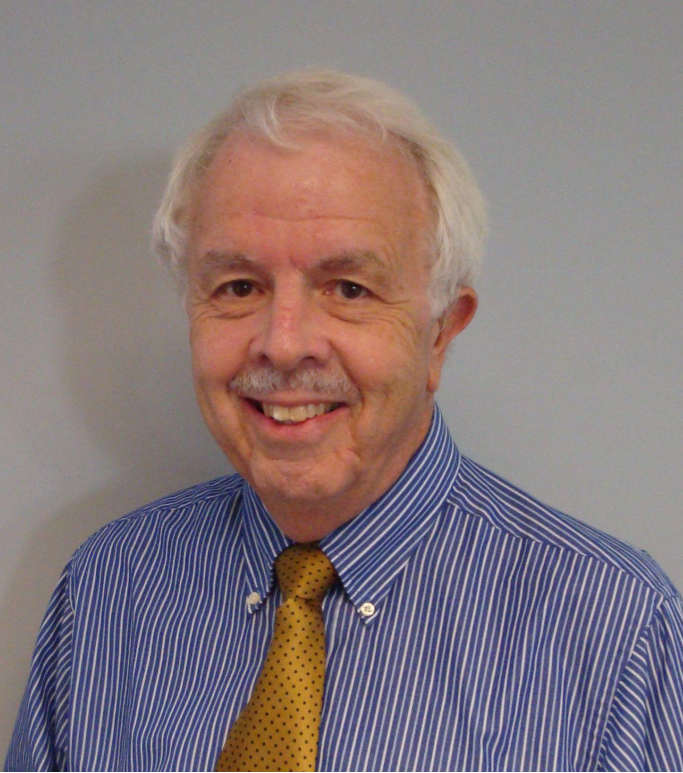

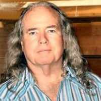

- Analogie zu natürlichen Vogelschwärmen
- PSO ist eine naturanaloge Metaheuristik
- Erste Anwendung in der Teilchenphysik

## Partikelschwarmoptimierung Grundlagen

Optimierungsproblem:

- Lösungsraum \(\Omega\) (z.b. \(\mathbb{R}^n\))
- Zielfunktion: \(f: \Omega \rightarrow \mathbb{R}\)
- Gesucht ist \(\omega \in \Omega\) für das \(f(\omega) = min\{f(x)|x \in \Omega\}\) gilt

Vehalten des PSO:

- Partikel bewegen sich im \(\mathbb{R}^n\) iterativ
- Partikel teilen sich Informationen
- Partikel haben ein Gedächtnis
- Partikel ändern ihren Richtungsvektor abhängig von 3 Faktoren
- Iteriere bis die Abbruchbedingung erreicht ist

## Standard PSO (SPSO)

1. Initialisiere zufällige Positionen \(x^{k, i}\) und Richtungsvektoren \(v^{k, i}\) der Partikel \(k\) in Iteration \(i=0\)
2. Evaluiere die Kostenfunktion mit der Position jedes Partikels
3. Speicher die bisher beste Position in \(g_{best}^i\)
4. Speicher die bisher beste Position pro Partikel in \(p_{best}^{k,i}\)
5. Iterationsschritt \(i \rightarrow i+1\) pro Partikel \(k\): \[ \begin{aligned} v^{k, i+1} &= w \cdot v^{k, i} + c_p \cdot r_1 \cdot (p_{best}^{k,i}-x^{k,i}) + c_g \cdot r_2 \cdot (g_{best}^{k,i}-x^{k,i}) \\ x^{k, i+1} &= x^{k, i} + v^{k, i+1} \end{aligned} \]
6. Wiederhole Schritt 2-5 bis die Abbruchbedingung erreicht ist

## SPSO Zeitschritt

\[ \begin{aligned} v^{k, i+1} &= w \cdot v^{k, i} + c_p \cdot r_1 \cdot (p_{best}^{k,i}-x^{k,i}) + c_g \cdot r_2 \cdot (g_{best}^{k,i}-x^{k,i}) \\ x^{k, i+1} &= x^{k, i} + v^{k, i+1} \end{aligned} \]

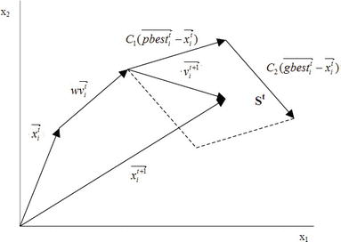

## Einfaches Beispiel

Zielfunktion:  
\[ \begin{aligned} f(x, y) =& -20\cdot e^{-0.2 \cdot \sqrt{0.5 \cdot ((x-1)^2 + (y-1)^2)}} \\ & \ - e^{0.5 \cdot ( cos(2\cdot \pi \cdot x) + cos(2\cdot \pi \cdot y))} + e + 20 \end{aligned} \] Aufgabe:  
Minimiere \(f(x,y)\) mit \(-10 \leq x \leq 10\) und \(-10 \leq y \leq 10\)

[PSO App](https://acrocode.shinyapps.io/PSO-App/)

## Nebenbedingungen

Beispiele:

- Summe soll 100% ergeben
- Summe der Gewichte von Elementen mit Ausprägung A soll weniger als 20% betragen
- Kosten sollen kleiner als 100 Euro sein
- Weniger als 20 Elemente sollen ungleich Null sein
- …

Methoden:

- Penalty
- Verwerfen von ungültigen Lösungen
- Reparieren von ungültigen Lösungen

## Penalty Methode

Alte Zielfunktion: \(f(x)\) mit \(f: \mathbb{R}^n \rightarrow \mathbb{R}\)

Bruch von Nebenbedingungen: \(g(x)\) mit \(g(x) \geq 0 \ \forall x \in \mathbb{R}^n\)

Neue Zielfunktion: \(z(x) = f(x) + g(x)\)

Beispiel für gängige Nebenbedingungen: \[ A^T \times x \geq b_0 \] Dann könnte \(g(x)\) wie folgt aussehen: \[ g(x) = ||\vec{\lambda}( A^T \times x - b_0 )||_2^2 \] mit elementweiser Anwendung von \[ \lambda(x) = \begin{cases} 0 &\text{ if }x \geq 0\\ x &\text{ if }x < 0 \end{cases} \]